# DATA605 Homework 7

Henry Otuadinma

11/10/2019

### 1. Let X1, X2, . . . , Xn be n mutually independent random variables, each of which is uniformly distributed on the integers from 1 to k. Let Y denote the minimum of the Xi’s. Find the distribution of Y .

#### Answer:

The minimum of the Xi’s (X1, X2, . . . , Xn) is denoted by Y, and each is uniformly distributed from 1 to k => each can be assumed to have k possibilities, therefore to find the distribution function P(X=m) of Y, I have to: - deduce the number of possible ways to assign the Xi’s to the values between m and k with at least one Xi being assigned to m - And deduce the total number of combinations to assign the Xi’s to values between 1 and k, that is, kn.

$k^n = $ Total combinations. $(k−1)^n = $ combinations where none of the Xi’s is equal to 1.

Similarly:

$P(X=2) = \frac{(k−2+1)^n−(k−2)^n}{k^n}$

$P(X=3) = \frac{(k−3+1)^n−(k−3)^n}{k^n}$

Generalizing this steps for the distribution function (X=m), then:

$P(X=m) = \frac{(k−m+1)^n−(k−m)^n}{k^n}$

#### SIMULATION

##### I am going to make plots to compare simulated and Theoretical Distributions of Y using 100, 000 trials

```r
sim <- function(k,n,trials=100000) {
  Y<-rep(0,trials)
  for (i in 1:trials) {
    x<-sample.int(k,size=n,replace=TRUE)
    Y[i]<-min(x)
  }
  return(Y)
}
```

##### first run at k = 100, and n = 20

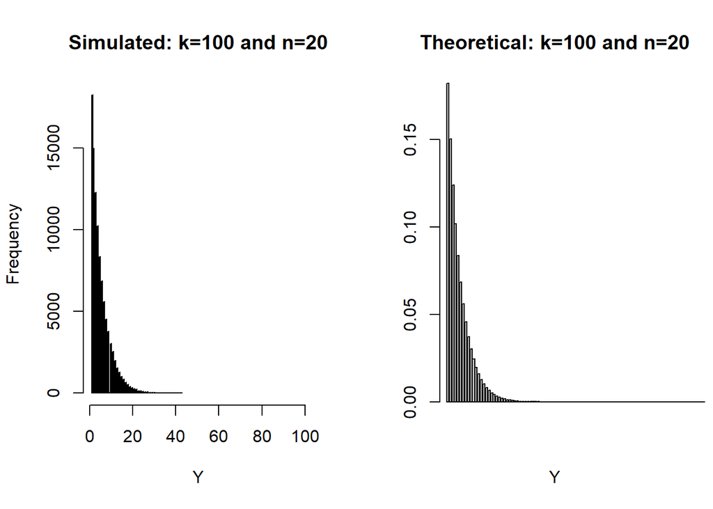

```r
par(mfrow=c(1,2))
k<-100
n<-20
hist(sim(k,n),breaks=60,main=paste("Simulated: k=",k," and n=",n,sep=""),xlab="Y",xlim=c(1,k))
pY<-((k-1:k+1)^n-(k-1:k)^n)/k^n
barplot(pY,main=paste("Theoretical: k=",k," and n=",n,sep=""),xlab="Y",xlim=c(1,k))
```

##### Second run at k = 100, and n = 5

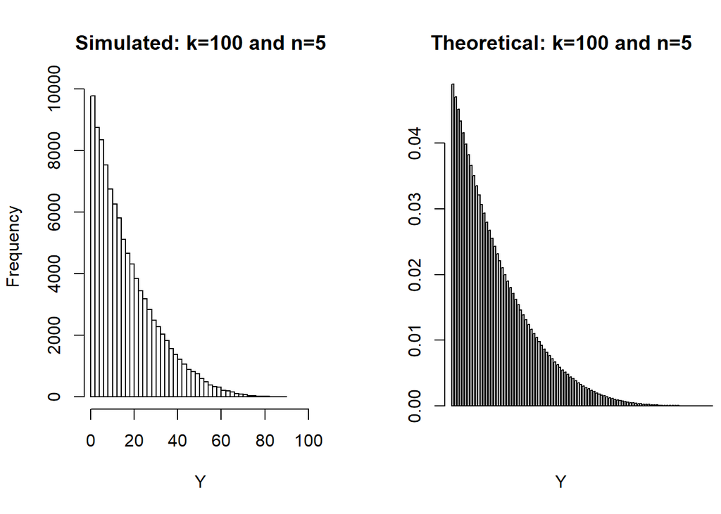

```r
par(mfrow=c(1,2))
k<-100
n<-5
hist(sim(k,n),breaks=60,main=paste("Simulated: k=",k," and n=",n,sep=""),xlab="Y",xlim=c(1,k))
pY<-((k-1:k+1)^n-(k-1:k)^n)/k^n
barplot(pY,main=paste("Theoretical: k=",k," and n=",n,sep=""),xlab="Y",xlim=c(1,k))
```

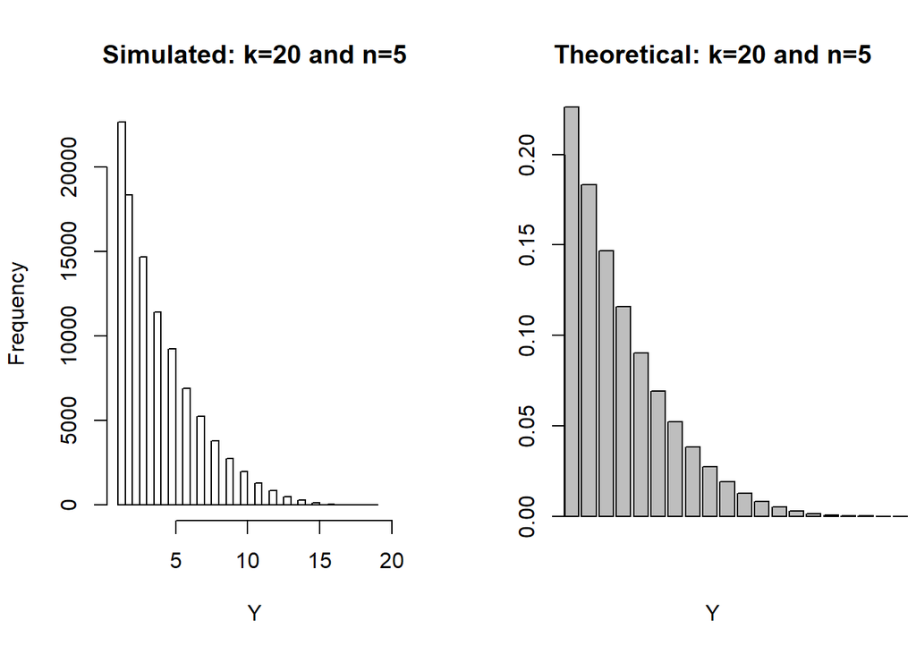

```r
par(mfrow=c(1,2))
k<-20
n<-5
hist(sim(k,n),breaks=60,main=paste("Simulated: k=",k," and n=",n,sep=""),xlab="Y",xlim=c(1,k))
pY<-((k-1:k+1)^n-(k-1:k)^n)/k^n
barplot(pY,main=paste("Theoretical: k=",k," and n=",n,sep=""),xlab="Y",xlim=c(1,k))
```

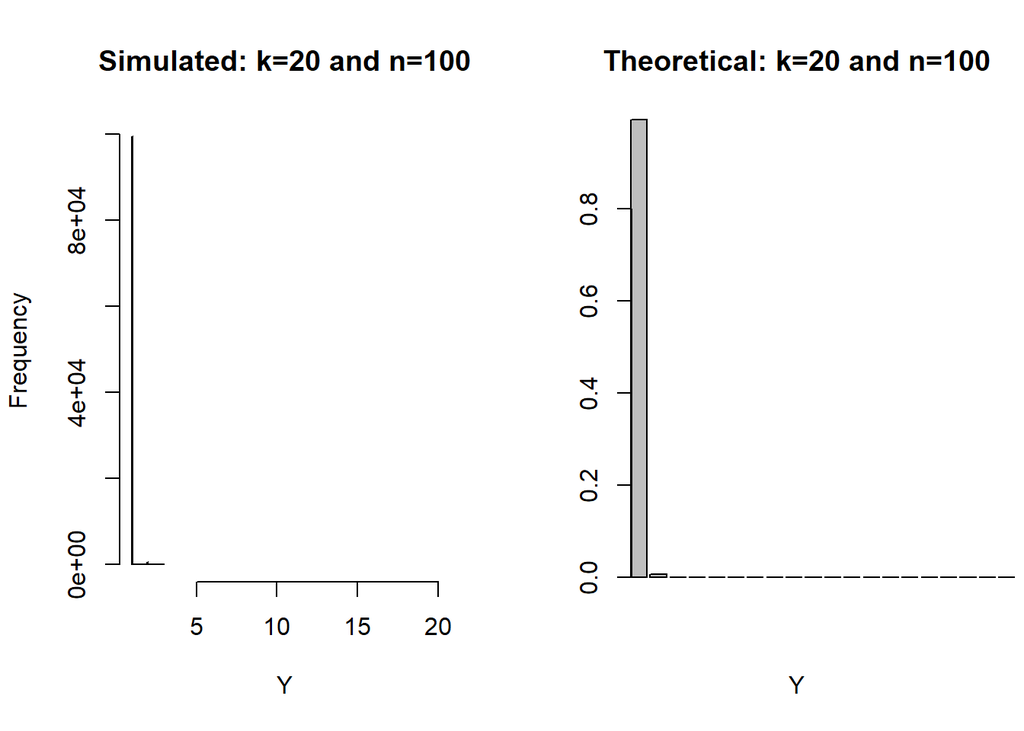

```r
par(mfrow=c(1,2))
k<-20
n<-100
hist(sim(k,n),breaks=60,main=paste("Simulated: k=",k," and n=",n,sep=""),xlab="Y",xlim=c(1,k))
pY<-((k-1:k+1)^n-(k-1:k)^n)/k^n
barplot(pY,main=paste("Theoretical: k=",k," and n=",n,sep=""),xlab="Y",xlim=c(1,k))
```

### 2. Your organization owns a copier (future lawyers, etc.) or MRI (future doctors). This machine has a manufacturer’s expected lifetime of 10 years. This means that we expect one failure every ten years. (Include the probability statements and R Code for each part.).

#### a. What is the probability that the machine will fail after 8 years?. Provide also the expected value and standard deviation. Model as a geometric. (Hint: the probability is equivalent to not failing during the first 8 years..)

##### Solution

This is a geometric distribution.

Since one failure occurs every ten years => $p=0.1 => q =1−p=0.9$

##### In probability distributions, a failure is considered a success.

$F_x(k) = P(X≤k)=1−q^{k+1}$: k = number of failures before the first success. In other words, $P(X>k)=1−P(X≤k)=1−(1−q^{k+1})=qk+1$. When k=8 => $P(X>8)=0.9^9 = 0.3874$.

Using R geometric distribution function

```r
pgeom(8, 0.1, lower.tail=FALSE)
```

```
## [1] 0.3874205
```

Therefore, The expected number of years before the first failure is $E(X)=\frac{q}{p}=\frac{0.9}{0.1}=9years$

Standard deviation $\sigma^2=\sqrt{\frac{q}{p^2}} = \sqrt{\frac{0.9}{0.12}} \approx{9.4868}$

#### b. What is the probability that the machine will fail after 8 years?. Provide also the expected value and standard deviation. Model as an exponential.

##### Solution

For the exponential distribution, CDF:

$FX(k)=P(X≤k)=1−e^{−λk}$, where λ = the rate parameter. We are given that λ=0.1 => $P(X>k)=1−P(X≤k)=1−(1−e^{−λk})=e^{−λk}$ When k=8 => $P(X>8)=e^{−0.8} \approx{0.4493}$ This can also be verified with R as follows:

```r
pexp(8, 0.1, lower.tail=FALSE)
```

```
## [1] 0.449329
```

Therefore expected value: $E(X)=\frac{1}{λ}=\frac{1}{0.1}=10$.

Standard deviation: $\sigma^2=\sqrt{\frac{1}{λ^2}} = \frac{1}{λ}=10$.

#### c. What is the probability that the machine will fail after 8 years?. Provide also the expected value and standard deviation. Model as a binomial. (Hint: 0 success in 8 years)

##### This is a binomial distribution.

Therefore, $P(X=k)=\binom{n}{k}p^kq^{n−k}$. As noted before, the Probability of a failure after 8 years = the probability of 0 successes after 8 trials. When k=0 and n=8 => $P(X=0)=\binom{8}{0}0.1^0×0.9^{8−0}=1×1×0.9^8 = 0.4305$

The expected value E(X) and will depend on number of years tracked.

For the first 8 years:

$E(X)=np=8×0.1=0.8$

Then

$\sigma = \sqrt{npq} = \sqrt{8×0.1×0.9} = 0.8485$.

#### d. What is the probability that the machine will fail after 8 years?. Provide also the expected value and standard deviation. Model as a Poisson.

##### This is a Poisson distribution

Since average number of failures in every 10 years is 1 so average number of failures in 8 years will be:

$λ=\frac{8}{10}=0.8$

Let X = failures in 8 years. The probability of 0 failures in 8 years will be =>

$P(X=0)=(\frac{λ^k}{k!}).e^{−λ} = (\frac{0.8^0}{0!}).e^{−0.8}=e^{−0.8}$

=> $P(X=0)=0.4493$

```r
ppois(0,0.1,lower.tail=TRUE)^8
```

```
## [1] 0.449329
```

E(X): $λ=0.8$

$\sigma = \sqrt{0.8} = 0.8944$ failures